# ProDy Tutorial: Gaussian Network Models

## GNM - Minimal Theory

[figure not shown]

The potential energy of a Gaussian Network Model is defined as the summation of harmonic potentials over all unique $(i,j)$-pairs and is a function of only the square of **inter-residue distance vector**, $\Delta \mathbf{R}_{ij} = \mathbf{R}_i - \mathbf{R}_j^0$. It can be given in terms of the **Kirchhoff matrix for inter-residue contacts**, $\mathbf{\Gamma}$,

$$ V^{GNM} = \frac{\gamma}{2} \Delta \mathbf{R}^T \left( \mathbf{\Gamma} \otimes \mathbf{I}_{3\times 3} \right) \Delta \mathbf{R} \,, $$

where $\mathbf{\Gamma}$ is an $(N \times N)$-matrix and is defined as:

$$ \mathbf{\Gamma}_{ij} = \left\{\begin{matrix} -1 & \text{if } i \ne j \text{ and }R_{ij} \le R_{cut} \,, \\ 0 & \text{if } i \ne j \text{ and }R_{ij} > R_{cut} \,, \\ -\sum_{j,j \ne i}^{N} \mathbf{\Gamma}_{ij} & \text{if } i = j \,. \end{matrix}\right. $$

## GNM Module

First, let's import all the required packages!

```python
from numpy import *
from matplotlib.pyplot import *
from prody import *
confProDy(auto_show=False)
confProDy(auto_secondary=True)
```

```
@> ProDy is configured: auto_show=False
@> ProDy is configured: auto_secondary=True
```

Parse the PDB structure for **adenylate kinase**.

```python
ake = parsePDB('4ake')
ake
```

```
@> PDB file is found in working directory (4ake.pdb).
@> 3459 atoms and 1 coordinate set(s) were parsed in 0.06s.
@> Secondary structures were assigned to 279 residues.
```

```
<AtomGroup: 4ake (3459 atoms)>
```

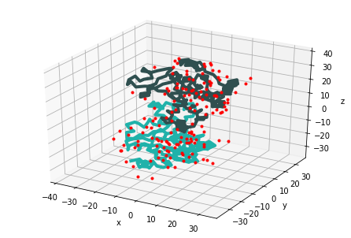

```python
showProtein(ake);
```

This PDB file contains 2 chains. If we only want to use $C^{\alpha}$ atoms from chain A, then we can select it as:

```python
calphas = ake.select('calpha and chain A')
calphas
```

```
<Selection: 'calpha and chain A' from 4ake (214 atoms)>
```

```python
calphas.numAtoms()
```

```
214
```

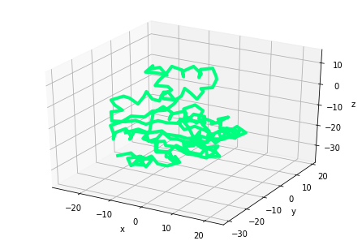

```python
showProtein(calphas);
```

*Tip:* how to access the documentation

- ProDy website: [reference manual](http://prody.csb.pitt.edu/manual/reference/index.html)
- see docstring of a method (?, ??)
- quick look at the parameter list (shift-Tab)
- jupyter syntax & shortcuts (h)

```python
parsePDB?
```

## Computing GNM normal modes

See also the [online tutorial](http://prody.csb.pitt.edu/tutorials/enm_analysis/gnm.html).

First, let's instantiate an object of GNM class.

```python
gnm = GNM('AKE')   # assign a name
```

Now, we can build the Kirchhoff matrix by the method buildKirchhoff.

What are the parameters of this method?

```python
gnm.buildKirchhoff?
```

Let's build Kirchhoff matrix based on the coordinate of $C^{\alpha}$-atoms already selected.

```python
gnm.buildKirchhoff(calphas)
```

```
@> Kirchhoff was built in 0.01s.
```

We can get the Kirchhoff matrix by the following method:

```python
gnm.getKirchhoff()
```

```
array([[17., -1., -1., ...,  0., -1.,  0.],
       [-1., 19., -1., ...,  0.,  0.,  0.],
       [-1., -1., 23., ...,  0., -1.,  0.],
       ...,
       [ 0.,  0.,  0., ..., 15., -1., -1.],
       [-1.,  0., -1., ..., -1., 15., -1.],
       [ 0.,  0.,  0., ..., -1., -1.,  7.]])
```

Check that every row sum is equal to 0 (since it is a Kirchhoff matrix!):

```python
apply_along_axis(sum, 1, gnm.getKirchhoff())
```

```
array([0., 0., 0., 0., 0., 0., 0., 0., 0., 0., 0., 0., 0., 0., 0., 0., 0.,
       0., 0., 0., 0., 0., 0., 0., 0., 0., 0., 0., 0., 0., 0., 0., 0., 0.,
       0., 0., 0., 0., 0., 0., 0., 0., 0., 0., 0., 0., 0., 0., 0., 0., 0.,
       0., 0., 0., 0., 0., 0., 0., 0., 0., 0., 0., 0., 0., 0., 0., 0., 0.,
       0., 0., 0., 0., 0., 0., 0., 0., 0., 0., 0., 0., 0., 0., 0., 0., 0.,
       0., 0., 0., 0., 0., 0., 0., 0., 0., 0., 0., 0., 0., 0., 0., 0., 0.,
       0., 0., 0., 0., 0., 0., 0., 0., 0., 0., 0., 0., 0., 0., 0., 0., 0.,
       0., 0., 0., 0., 0., 0., 0., 0., 0., 0., 0., 0., 0., 0., 0., 0., 0.,
       0., 0., 0., 0., 0., 0., 0., 0., 0., 0., 0., 0., 0., 0., 0., 0., 0.,
       0., 0., 0., 0., 0., 0., 0., 0., 0., 0., 0., 0., 0., 0., 0., 0., 0.,
       0., 0., 0., 0., 0., 0., 0., 0., 0., 0., 0., 0., 0., 0., 0., 0., 0.,
       0., 0., 0., 0., 0., 0., 0., 0., 0., 0., 0., 0., 0., 0., 0., 0., 0.,
       0., 0., 0., 0., 0., 0., 0., 0., 0., 0.])
```

Degrees of residues:

```python
diag(gnm.getKirchhoff())
```

```
array([17., 19., 23., 20., 21., 24., 21., 21., 15., 17., 21., 16., 21.,
       15., 13., 17., 16., 13., 14., 21., 16., 10., 12., 16., 16., 20.,
       20., 19., 19., 14., 17.,  8., 10., 16., 21., 14., 16., 20., 18.,
       11., 11., 13., 13., 10., 17., 20., 14., 15., 24., 20., 13., 14.,
       14.,  9.,  9.,  9., 11., 10., 15., 11., 15., 11., 15., 20., 19.,
       14., 20., 19., 15., 14., 17., 17., 11.,  9.,  9., 13., 18., 13.,
       12., 20., 22., 24., 21., 18., 17., 17., 22., 14., 16., 18., 11.,
       17., 19., 14., 15., 20., 12., 10., 11.,  9., 15., 14., 20., 16.,
       21., 22., 21., 20., 21., 17., 20., 12., 17., 10., 12., 19., 20.,
       15., 17., 20., 21., 17., 21., 25., 20., 22., 15.,  9., 10.,  8.,
       13., 18., 22., 17., 14., 11., 10., 11., 18., 19., 11., 11., 14.,
       18., 19., 23., 16., 11., 10., 12., 14., 15., 21., 16., 17., 15.,
       11., 12., 18., 15., 15., 12., 13., 21., 17., 11., 15., 17., 13.,
       11., 15., 14., 10., 14., 19., 12., 13., 20., 21., 12., 15., 21.,
       18., 14., 14., 17., 11., 10., 10., 16., 18., 19., 22., 16., 14.,
       19., 15., 20., 16., 12., 10., 12., 10., 12., 18., 17., 11., 14.,
       17., 12.,  9., 15., 15.,  7.])
```

## Calculate normal modes

We can calculate normal modes from the Kirchhoff matrix by the method calcModes. Many parameters in this function can be adjusted, e.g. the number of modes: [calcModes( ) doc](http://prody.csb.pitt.edu/manual/reference/dynamics/gnm.html?highlight=gnm#prody.dynamics.gnm.GNM.calcModes)

```python
gnm.calcModes?
```

```python
gnm.calcModes(n_modes=10)
gnm.calcModes(10)
gnm.calcModes(n_modes=None)   # or: (n_modes='all')
gnm.calcModes(n_modes=None, zeros=True)
```

```
@> 10 modes were calculated in 0.01s.
@> 10 modes were calculated in 0.00s.
@> 213 modes were calculated in 0.05s.
@> 214 modes were calculated in 0.05s.
```

The algebraic multiplicity of zero eigenvalues determines separate connected components of your graph.

If it is equal to *one*, then your graph does not have **a disconnected piece!**

Get eigenvalues and eigenvectors:

```python
gnm.getEigvals().round(3)
```

```
array([ 0.   ,  0.269,  0.721,  1.724,  1.818,  2.47 ,  3.163,  3.644,
        4.007,  4.487,  4.735,  5.081,  5.513,  5.861,  5.958,  6.354,
        6.878,  7.008,  7.811,  8.366,  8.483,  8.655,  8.907,  9.241,
        9.436,  9.692,  9.72 ,  9.812,  9.902, 10.   , 10.029, 10.166,
       10.2  , 10.259, 10.356, 10.5  , 10.583, 10.672, 10.83 , 10.914,
       10.968, 11.073, 11.079, 11.178, 11.228, 11.319, 11.348, 11.587,
       11.602, 11.666, 11.713, 11.832, 11.876, 11.891, 12.057, 12.155,
       12.237, 12.32 , 12.364, 12.393, 12.556, 12.627, 12.682, 12.745,
       12.808, 12.905, 12.985, 13.023, 13.149, 13.213, 13.335, 13.364,
       13.424, 13.493, 13.531, 13.602, 13.63 , 13.674, 13.711, 13.863,
       13.974, 14.019, 14.074, 14.175, 14.252, 14.346, 14.413, 14.528,
       14.566, 14.678, 14.729, 14.857, 14.876, 14.903, 14.94 , 15.025,
       15.117, 15.178, 15.248, 15.265, 15.379, 15.465, 15.548, 15.686,
       15.714, 15.767, 15.867, 15.966, 16.03 , 16.05 , 16.147, 16.245,
       16.337, 16.351, 16.416, 16.49 , 16.578, 16.632, 16.715, 16.786,
       16.824, 16.865, 16.885, 17.059, 17.121, 17.179, 17.272, 17.295,
       17.345, 17.396, 17.551, 17.605, 17.663, 17.746, 17.781, 17.928,
       17.963, 17.988, 18.106, 18.246, 18.296, 18.326, 18.382, 18.408,
       18.62 , 18.675, 18.729, 18.85 , 18.913, 18.99 , 19.061, 19.219,
       19.314, 19.358, 19.406, 19.463, 19.571, 19.65 , 19.679, 19.693,
       19.771, 19.896, 20.026, 20.158, 20.218, 20.267, 20.427, 20.534,
       20.677, 20.813, 20.886, 20.938, 20.975, 21.114, 21.186, 21.307,
       21.334, 21.408, 21.515, 21.53 , 21.639, 21.657, 21.857, 21.914,
       21.971, 21.991, 22.112, 22.172, 22.226, 22.364, 22.476, 22.607,
       22.665, 22.744, 22.89 , 22.981, 23.052, 23.193, 23.308, 23.44 ,
       23.563, 23.614, 23.776, 23.825, 23.863, 23.997, 24.313, 24.543,
       24.7  , 25.114, 25.46 , 25.824, 26.466, 26.525])
```

```python
gnm.getEigvecs().round(3)
```

```
array([[-0.068, -0.038, -0.048, ...,  0.038, -0.002,  0.   ],
       [-0.068, -0.038, -0.043, ...,  0.002,  0.034, -0.003],
       [-0.068, -0.034, -0.05 , ..., -0.289, -0.35 ,  0.028],
       ...,
       [-0.068, -0.024, -0.082, ..., -0.018, -0.013,  0.001],
       [-0.068, -0.03 , -0.074, ..., -0.001,  0.032, -0.002],
       [-0.068, -0.029, -0.087, ...,  0.002,  0.001, -0.   ]])
```

*NB:* the zeroth eigenvector is always constant and the corresponding eigenvalue is 0.

How about the variances:

```python
gnm.getVariances()[1:].round(3)
```

```
array([3.713, 1.387, 0.58 , 0.55 , 0.405, 0.316, 0.274, 0.25 , 0.223,
       0.211, 0.197, 0.181, 0.171, 0.168, 0.157, 0.145, 0.143, 0.128,
       0.12 , 0.118, 0.116, 0.112, 0.108, 0.106, 0.103, 0.103, 0.102,
       0.101, 0.1  , 0.1  , 0.098, 0.098, 0.097, 0.097, 0.095, 0.094,
       0.094, 0.092, 0.092, 0.091, 0.09 , 0.09 , 0.089, 0.089, 0.088,
       0.088, 0.086, 0.086, 0.086, 0.085, 0.085, 0.084, 0.084, 0.083,
       0.082, 0.082, 0.081, 0.081, 0.081, 0.08 , 0.079, 0.079, 0.078,
       0.078, 0.077, 0.077, 0.077, 0.076, 0.076, 0.075, 0.075, 0.074,
       0.074, 0.074, 0.074, 0.073, 0.073, 0.073, 0.072, 0.072, 0.071,
       0.071, 0.071, 0.07 , 0.07 , 0.069, 0.069, 0.069, 0.068, 0.068,
       0.067, 0.067, 0.067, 0.067, 0.067, 0.066, 0.066, 0.066, 0.066,
       0.065, 0.065, 0.064, 0.064, 0.064, 0.063, 0.063, 0.063, 0.062,
       0.062, 0.062, 0.062, 0.061, 0.061, 0.061, 0.061, 0.06 , 0.06 ,
       0.06 , 0.06 , 0.059, 0.059, 0.059, 0.059, 0.058, 0.058, 0.058,
       0.058, 0.058, 0.057, 0.057, 0.057, 0.057, 0.056, 0.056, 0.056,
       0.056, 0.056, 0.055, 0.055, 0.055, 0.055, 0.054, 0.054, 0.054,
       0.054, 0.053, 0.053, 0.053, 0.053, 0.052, 0.052, 0.052, 0.052,
       0.052, 0.051, 0.051, 0.051, 0.051, 0.051, 0.051, 0.05 , 0.05 ,
       0.05 , 0.049, 0.049, 0.049, 0.049, 0.048, 0.048, 0.048, 0.048,
       0.048, 0.047, 0.047, 0.047, 0.047, 0.047, 0.046, 0.046, 0.046,
       0.046, 0.046, 0.046, 0.046, 0.045, 0.045, 0.045, 0.045, 0.045,
       0.044, 0.044, 0.044, 0.044, 0.044, 0.044, 0.043, 0.043, 0.043,
       0.043, 0.042, 0.042, 0.042, 0.042, 0.042, 0.042, 0.041, 0.041,
       0.04 , 0.04 , 0.039, 0.039, 0.038, 0.038])
```

*NB:* A more compact way to compute GNM is to use the function [calcGNM( ) doc](http://prody.csb.pitt.edu/manual/reference/dynamics/gnm.html?highlight=gnm#prody.dynamics.gnm.calcGNM)

## How to plot results

```python
gnm.calcModes()   # default = 20 modes
```

```
@> 20 modes were calculated in 0.01s.
```

The contact map can be visualized with the command:

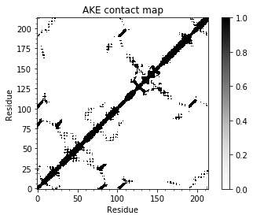

```python
showContactMap(gnm, cmap='Greys');
```

...while the shape of normal modes can be visualized by typing:

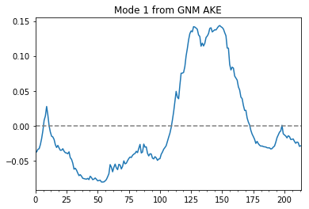

```python
showMode(gnm[0]);
```

We can show possible hinge sites on that plot as well.

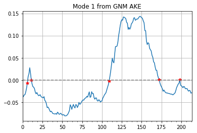

```python
showMode(gnm[0], hinges=True);
```

**Furthermore**, you can also access hinge sites identified from multiple modes (e.g. 2 modes) by:

```python
gnm[:2].getHinges()
```

```
[6, 11, 28, 74, 91, 94, 95, 97, 100, 109, 120, 156, 172, 198]
```

Many other visualization tools can be found online at the page [Plotting Functions](http://prody.csb.pitt.edu/manual/reference/dynamics/plotting.html?).

## GNM covariance and (normalized/orientational) cross-correlation matrices

Let's get the covariance matrix first, $C_{ij} \propto \sum_{i=1}^{N-1} \lambda_i^{-1} \mathbf{u}_i \mathbf{u}_i^T$:

```python
cov = gnm.getCovariance()
cov.shape
```

```
(214, 214)
```

```python
cov
```

```
array([[0.02235368, 0.01863088, 0.01536492, ..., 0.00840091, 0.01409038,
        0.01147617],
       [0.01863088, 0.01745801, 0.01497417, ..., 0.00786158, 0.01168132,
        0.0059725 ],
       [0.01536492, 0.01497417, 0.01395891, ..., 0.00993459, 0.01210848,
        0.00661435],
       ...,
       [0.00840091, 0.00786158, 0.00993459, ..., 0.02689691, 0.02338466,
        0.03495323],
       [0.01409038, 0.01168132, 0.01210848, ..., 0.02338466, 0.0241067 ,
        0.03944248],
       [0.01147617, 0.0059725 , 0.00661435, ..., 0.03495323, 0.03944248,
        0.16032265]])
```

Alternative ways to compute the covariance and (normalized/orientational) cross-correlation matrix, $C_{ij}^{(n)} = C_{ij} \big/ \left(C_{ii} C_{jj} \right)^{1/2}$:

```python
C1 = calcCovariance(gnm)

# again covariance matrix for GNM, not for ANM!
C2 = calcCrossCorr(gnm, norm=False)

# normalized/orientational cross-correlation matrix
C3 = calcCrossCorr(gnm)
```

```python
all(C1 == cov)
```

```
True
```

```python
all(C2 == cov)
```

```
True
```

```python
all(C3 == cov)
```

```
False
```

```python
C3
```

```
array([[1.        , 0.94310805, 0.86982101, ..., 0.34261045, 0.60698702,
        0.19170129],
       [0.94310805, 1.        , 0.95922324, ..., 0.36279501, 0.56941066,
        0.11289159],
       [0.86982101, 0.95922324, 1.        , ..., 0.51271113, 0.6600774 ,
        0.13981819],
       ...,
       [0.34261045, 0.36279501, 0.51271113, ..., 1.        , 0.91835592,
        0.53227809],
       [0.60698702, 0.56941066, 0.6600774 , ..., 0.91835592, 1.        ,
        0.63445073],
       [0.19170129, 0.11289159, 0.13981819, ..., 0.53227809, 0.63445073,
        1.        ]])
```

We can visualize the **normalized/orientational** cross-correlations between residue fluctuations with the command:

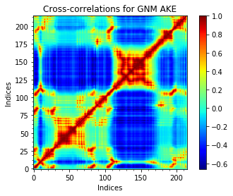

```python
showCrossCorr(gnm);
```

The residues' **mean square fluctuations (MSF)** are found on the diagonal of the covariance matrix and describe the residue mobility or flexibility.

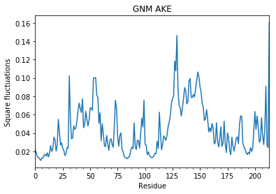

```python
# MSFs from all computed modes

showSqFlucts(gnm);
```

**Moreover**, you can specify the number of modes to compute the MSFs to see either their indivudual or cumulative contributions visually as well!

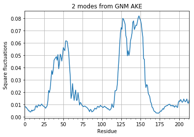

```python
# square fluctuations computed from 2 slowest (lowest-energy) modes

showSqFlucts(gnm[:2])
grid();
```

We can also see how well the computed MSF correlates with the **experimental B-factors** *(Debye-Waller)* extracted from the PDB file:

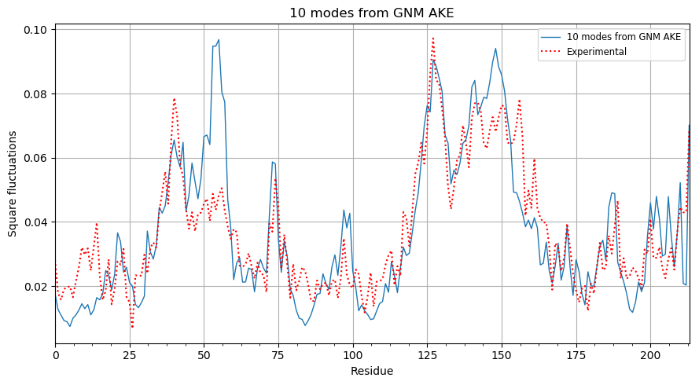

```python
# rescale B-factors

bfactors = calphas.getBetas()
bfactors = bfactors / mean(bfactors) * mean(calcSqFlucts(gnm[:10]))

figure(figsize=(9, 5), dpi=100)
showSqFlucts(gnm[:10], lw=1)
plot(bfactors, 'r:', label='Experimental')
grid()
legend(fontsize='small')
tight_layout();
```

Let's evaluate Pearson's correlation coefficient between experimental B-factors and GNM predicted MSFs:

```python
corrcoef(calphas.getBetas(), calcSqFlucts(gnm))[0, 1]
```

```
0.8034453917904311
```

## Visualize MSFs on protein's 3D structure

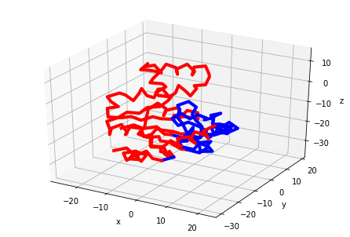

```python
showProtein(calphas, mode=gnm[0]);
```

GNM modes and square fluctuations can also be saved in *.nmd* format and visualized with the VMD plugin **NMWizard**:

```python
writeNMD('AKE_gnm.nmd', gnm, calphas)
```

```
'AKE_gnm.nmd'
```

```python
! vmd -e AKE_gnm.nmd
```

Alternatively, MSFs can be stored in the *tempFactor* column of a PDB file and again visualized in VMD:

```python
msf_10 = calcSqFlucts(gnm[:10])
writePDB('AKE-sqFlucts_on_beta.pdb', calphas, beta=msf_10)
```

```
'AKE-sqFlucts_on_beta.pdb'
```

```python
! vmd AKE-sqFlucts_on_beta.pdb
```

## Caveat - flexible loops/termini

```
@> PDB file is found in working directory (1aar.pdb).
@> 76 atoms and 1 coordinate set(s) were parsed in 0.00s.
@> Secondary structures were assigned to 47 residues.
@> Kirchhoff was built in 0.00s.
@> 20 modes were calculated in 0.01s.
```

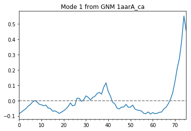

```python
ubi = parsePDB('1aar', chain='A', subset='calpha')
ubi_gnm, ubi_calphas = calcGNM(ubi, cutoff=10)
showMode(ubi_gnm[0]);
```

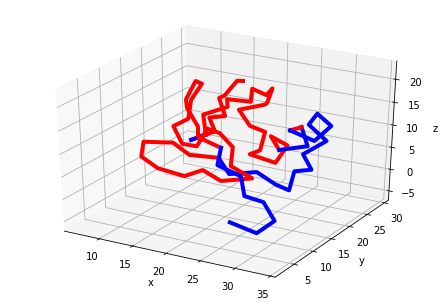

```python
showProtein(ubi_calphas, mode=ubi_gnm[0]);
```

The unfolded C-terminal (residues 71-76) of ubiquitin is particularly flexible and its contribution to total residue fluctuations is dominant. We then need to exclude it from the analysis:

```
@> Kirchhoff was built in 0.01s.
@> 20 modes were calculated in 0.00s.
```

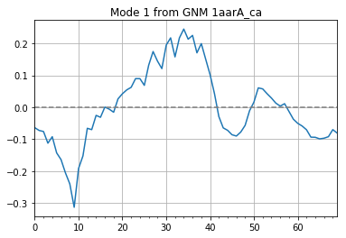

```python
ubi_gnm_fixed, ubi_calphas_fixed = calcGNM(ubi.select('resnum < 71'), cutoff=10)
showMode(ubi_gnm_fixed[0])
grid();
```

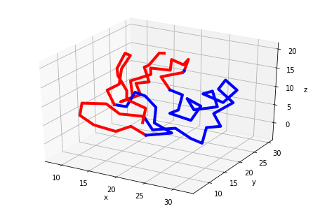

```python
showProtein(ubi_calphas_fixed, mode=ubi_gnm_fixed[0]);
```

Let's look at the effect of those residues on the collectivity of a particular mode, whose degree basically reflects the number of atoms which are significantly affected by that mode. It is defined as the exponential of the information entropy of that mode: calcCollectivity

```python
calcCollectivity(ubi_gnm[0])
```

```
0.1548417245762932
```

```python
calcCollectivity(ubi_gnm_fixed[0])
```

```
0.5030864935567456
```

We can easily compute the collectivity of a set of modes at once!

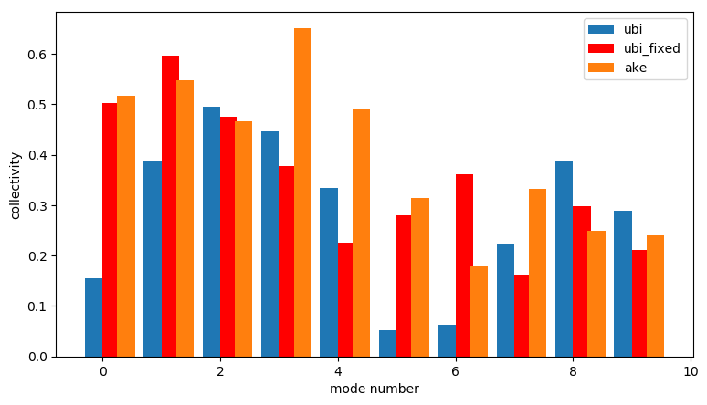

```python
figure(figsize=(9, 5), dpi=100)
bar(arange(10)-0.15, calcCollectivity(ubi_gnm[:10]),  width=.3, label='ubi')
bar(arange(10)+0.15, calcCollectivity(ubi_gnm_fixed[:10]), width=.3, color='r', label='ubi_fixed')
bar(arange(10)+0.4, calcCollectivity(gnm[:10]), width=.3, label='ake')
xlabel('mode number')
ylabel('collectivity')
legend();
```